# Project - Database Model Comparison

# The Implementation Dataset : University Enrollment Data

###### 12/12/2020 / By Jonathan Njeunje

## Introduction

The main idea of this project is the comparison of three types of the databases: differences in design approach, implementation, query composition and performance.

The general approaches we will follow is to create 3 copies of the same database. Create three databases and an application working with all three. One - relational DB Oracle, MongoDB, and Neo4j.

### Scenario

For this implemenetatio we will use the following dataset:

The University Enrollment database - A database that keeps information geared towards students’ enrollment in the university: their majors, year enrolled, classes taken, grades received, withdrawals, etc. Also their background info, age, gender, high-school attended, home address, current housing arrangements (dorm, rent, parents) etc. The application should be able to answer , from “Which major has the most students retained after the first year?” to “What course has the highest percent of people with grade W?”, “What’s a 4-year graduation rate among the female students, grouped by housing arrangements?”, etc.

### Selected Queries

- Which major has the most students retained after the first year?
- What course has the highest percent of people with grade W?
- What’s a 4-year graduation rate among the female students, grouped by majors?
- Rank all courses in terms of their popularity (cumulated number enrollments).
- What is the trend of enrollment over the years?
- How does the number of full-time students vs part-time students compare for both graduate and undergraduate students?
- What are the percentages of female vs male students in STEM programs?
- What is the distribution of students with respect to their race?
- What is the percentage of enrollment per state in the USA?
- Which instructor is most "effective" in the long run? - 80%*score+20%*absenceRate
- What is the most popular course (based on enrollment count) With respect to the country of origin?

## Required Installs

```python
# pip install requests
```

```python
# pip install cx_Oracle --upgrade
```

```python
# pip install neo4j-driver
```

## Required Libraries

```python
# Global imports
import pprint # for pretty printing
import numpy as np
import json
import glob
```

```python
# Benchmark

# Find out what type of Python we running
import sys
# https://www.geeksforgeeks.org/python-measure-time-taken-by-program-to-execute/
# Code to Measure time taken by program to execute.
import time
import math

import pandas as pds
pds.set_option('display.max_colwidth', -1)
```

```python
# Data Generation
import requests
```

```python
# Ref: https://www.heatonresearch.com/content/oracle.html
# Use the directory you unzipped the instant client to:
import os
# sys.path.insert(1, 'c:\\Oracle\\instantclient_19_9')
# workspace_dir = os.getcwd()
# oracle_instantclient_dir = "C:\\Oracle\\instantclient_19_9"
# os.chdir(oracle_instantclient_dir)
import cx_Oracle
# os.chdir(workspace_dir)
# display(sys.path)
```

```python
# MongoDB
import pymongo
from pymongo import MongoClient
```

```python
# Neo4j
from neo4j import GraphDatabase
```

```python
# Benchmark
import matplotlib.pyplot as plt
```

## Benchmark

### Criteria:

- The execution time
- The features availability

### Configuration

#### Python Environment:

```python
print("Python version: " + sys.version)
```

```
Python version: 3.7.3 (default, Apr 24 2019, 15:29:51) [MSC v.1915 64 bit (AMD64)]
```

#### Oracle Environment:

- Environment: Online, Linux OS
- Version: 12.1.0.2.0

#### MongoDB Environment:

- Environment: Online, Linux OS, arch: x86_64
- Version: 4.2.11

#### Neo4j Environment:

- Environment: Localhost, Windows OS, 64
- Version: 4.2.1

## Data Generator

- The mock data is generated from www.mockaroo.com.
- Different schemas and APIs (to those schemas) where used to generate the mock data.
- The account use at amockaroo.com, is a free limited account to a 1000 records per API calls, with a max of 200 API calls per 24 hrs

```python
# # function to add to JSON
# def write_data_to_json(data, filename='file.json'):
#     data_uni = []
#     for batch in data:
#         for record in batch:
#             data_uni.append(record)

#     with open(filename,'w') as f:
#         json.dump(data_uni, f, indent=4)

#     print("Records count:", len(data_uni))
```

```python
# # function to add to JSON
# def write_data_to_json(data, filename='file.json', append = 0):

#     data_uni = []
#     for batch in data:
#         for record in batch:
#             data_uni.append(record)

#     if append == 1:
#         with open(filename) as json_file:
#             try:
#                 temp = json.load(json_file)
#             except:
#                 temp = []
#             temp.append(data_uni)
#             data_uni = temp
#     print("Records count:", len(data_uni))

#     with open(filename,'w') as json_file:
#         json.dump(data_uni, json_file, indent=4)

# # json_file.close()
```

### Major:

```python
# api_call = "https://my.api.mockaroo.com/universityenrollment_major.json?key=8e82cd00"
# number_requests = 1

# status_code = []
# data = []
# for idx in range(number_requests):
#     response = requests.get(api_call)
#     status_code.append(response.status_code)
#     data.append(response.json())
# print("API call status code: ", status_code)

# write_data_to_json(data, "dataset/UniversityEnrollment_Major.json")
```

### Student:

```python
# api_call = "https://my.api.mockaroo.com/universityenrollment_student.json?key=8e82cd00"
# number_requests = 30

# status_code = []
# data = []
# for idx in range(number_requests):
#     init_ID = (1000 * idx)
#     parameters = {
#         "init_ID": init_ID
#     }
#     response = requests.get(api_call, params = parameters)
#     status_code.append(response.status_code)
#     data.append(response.json())
# print("API call status code: ", status_code)

# batch = len(glob.glob("dataset/student/*.json")) + 1

# write_data_to_json(data, "dataset/student/UniversityEnrollment_Student_" + str(batch) + ".json")
```

```python
data = []
for file in glob.glob("dataset/student/*.json"):
    with open(file, "r") as json_file:
        data.append(json.load(json_file))


idx = 1
data_uni = []
std_limit = 100000
for batch in data:
    for record in batch:
        std_limit -= 1
        if std_limit < 0: break
        record["Student"]["ID"] = idx
        data_uni.append(record)
        idx += 1

display(len(data_uni))
with open("dataset/UniversityEnrollment_Student.json", "w") as json_file:
     json.dump(data_uni, json_file, indent = 4)
```

```
100000
```

### Enrollment:

```python
# api_call = "https://my.api.mockaroo.com/universityenrollment_enrollment.json?key=8e82cd00"
# number_requests = 40

# status_code = []
# data = []
# for idx in range(number_requests):
#     response = requests.get(api_call)
#     status_code.append(response.status_code)
#     data.append(response.json())
# print("API call status code: ", status_code)

# batch = len(glob.glob("dataset/enrollment/*.json")) + 1

# write_data_to_json(data, "dataset/enrollment/UniversityEnrollment_Enrollment_" + str(batch) + ".json")
```

```python
data = []
for file in glob.glob("dataset/enrollment/*.json"):
    with open(file, "r") as json_file:
        data.append(json.load(json_file))

std_limit = 100000 # make sure it equal that from the student's section.
enr_limit = 200000
data_uni = []
for batch in data:
    for record in batch:
        enr_limit -= 1
        if enr_limit < 0: break
        record["Student"]["ID"] = (record["Student"]["ID"] % (std_limit - 1)) + 1 # Rematching the student IDs
        data_uni.append(record)


display(len(data_uni))
with open("dataset/UniversityEnrollment_Enrollment.json", "w") as json_file:
     json.dump(data_uni, json_file, indent = 4)
```

```
200000
```

## Databases Modeling and Loading

### Oracle

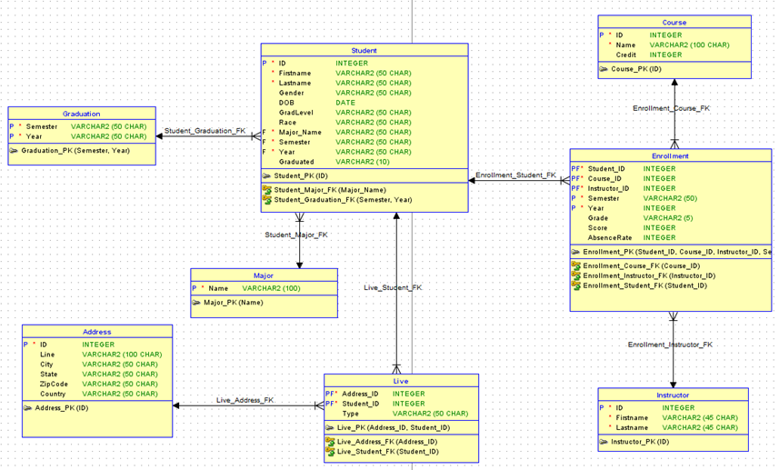

#### Connection to the Database:

To connect to the oracle database we need to download and install the instant_client

For Windows machines, you can follow https://www.oracle.com/database/technologies/instant-client/winx64-64-downloads.html and download a basic instant client (version 19.9). Follow the installation instructions on https://www.oracle.com/database/technologies/instant-client/winx64-64-downloads.html#ic_winx64_inst.

Other Ref: https://oracle.github.io/python-cx_Oracle/

- There is an oracle database restriction of 50MB for every user. The dataset had to be scaled down to 100000 student records and 200000 enrollment records

```python
# myscript.py
host = "oracle1.wiu.edu"
port = "1521"
sid = "toolman"
user = "ajmn100"
password = "CS523_3907"

dsn_tns = cx_Oracle.makedsn(host, port, sid=sid) #if connecting to WIU Oracle server
# OR
#dsn_tns = cx_Oracle.makedsn(host, port, service_name=sid) #if connecting to localhost

# Connect as user with password to the dsn service.
oracle_connection = cx_Oracle.connect(user=user, password=password, dsn=dsn_tns,  encoding="UTF-8", nencoding="UTF-8")
```

##### Verify Connection:

```python
print("Connected to Oracle: " + oracle_connection.version)
```

```
Connected to Oracle: 12.1.0.2.0
```

```python
oracle_cursor = oracle_connection.cursor()
```

#### Reset Database:

```python
def runsqllines(sqllines):
    for sql in sqllines.split(";"):
        if sql.strip() == "": continue
        try:
            oracle_cursor.execute(sql)
        except Exception as e:
            print(e)
```

```python
def reset_oracle():
    sqllines = """
    DROP TABLE enrollment CASCADE CONSTRAINTS;
    DROP TABLE live CASCADE CONSTRAINTS;
    DROP TABLE course CASCADE CONSTRAINTS;
    DROP TABLE instructor CASCADE CONSTRAINTS;
    DROP TABLE student CASCADE CONSTRAINTS;
    DROP TABLE graduation CASCADE CONSTRAINTS;
    DROP TABLE major CASCADE CONSTRAINTS;
    DROP TABLE address CASCADE CONSTRAINTS;
    """
    runsqllines(sqllines)

    sqllines= """
    CREATE TABLE address (
        id       INTEGER NOT NULL,
        line     VARCHAR2(100 CHAR),
        city     VARCHAR2(50 CHAR),
        state    VARCHAR2(50 CHAR),
        zipcode  VARCHAR2(50 CHAR),
        country  VARCHAR2(50 CHAR)
    );

    ALTER TABLE address ADD CONSTRAINT address_pk PRIMARY KEY ( id );

    CREATE TABLE course (
        id      INTEGER NOT NULL,
        name    VARCHAR2(100 CHAR) NOT NULL,
        credit  INTEGER
    );

    ALTER TABLE course ADD CONSTRAINT course_pk PRIMARY KEY ( id );

    CREATE TABLE enrollment (
        student_id     INTEGER NOT NULL,
        course_id      INTEGER NOT NULL,
        instructor_id  INTEGER NOT NULL,
        semester       VARCHAR2(50) NOT NULL,
        year           INTEGER NOT NULL,
        grade          VARCHAR2(5),
        score          INTEGER,
        absencerate    INTEGER
    );

    ALTER TABLE enrollment
        ADD CONSTRAINT enrollment_pk PRIMARY KEY ( student_id,
                                                   course_id,
                                                   instructor_id,
                                                   semester,
                                                   year );

    CREATE TABLE graduation (
        semester  VARCHAR2(50 CHAR) NOT NULL,
        year      VARCHAR2(50 CHAR) NOT NULL
    );

    ALTER TABLE graduation ADD CONSTRAINT graduation_pk PRIMARY KEY ( semester,
                                                                      year );

    CREATE TABLE instructor (
        id         INTEGER NOT NULL,
        firstname  VARCHAR2(45 CHAR) NOT NULL,
        lastname   VARCHAR2(45 CHAR) NOT NULL
    );

    ALTER TABLE instructor ADD CONSTRAINT instructor_pk PRIMARY KEY ( id );

    CREATE TABLE live (
        address_id  INTEGER NOT NULL,
        student_id  INTEGER NOT NULL,
        type        VARCHAR2(50 CHAR)
    );

    ALTER TABLE live ADD CONSTRAINT live_pk PRIMARY KEY ( address_id,
                                                          student_id );

    CREATE TABLE major (
        name VARCHAR2(100) NOT NULL
    );

    ALTER TABLE major ADD CONSTRAINT major_pk PRIMARY KEY ( name );

    CREATE TABLE student (
        id          INTEGER NOT NULL,
        firstname   VARCHAR2(50 CHAR) NOT NULL,
        lastname    VARCHAR2(50 CHAR) NOT NULL,
        gender      VARCHAR2(50 CHAR),
        dob         DATE,
        gradlevel   VARCHAR2(50 CHAR),
        race        VARCHAR2(50 CHAR),
        major_name  VARCHAR2(50 CHAR) NOT NULL,
        semester    VARCHAR2(50 CHAR) NOT NULL,
        year        VARCHAR2(50 CHAR) NOT NULL,
        graduated   VARCHAR2(10)
    );

    ALTER TABLE student ADD CONSTRAINT student_pk PRIMARY KEY ( id );

    ALTER TABLE enrollment
        ADD CONSTRAINT enrollment_course_fk FOREIGN KEY ( course_id )
            REFERENCES course ( id );

    ALTER TABLE enrollment
        ADD CONSTRAINT enrollment_instructor_fk FOREIGN KEY ( instructor_id )
            REFERENCES instructor ( id );

    ALTER TABLE enrollment
        ADD CONSTRAINT enrollment_student_fk FOREIGN KEY ( student_id )
            REFERENCES student ( id );

    ALTER TABLE live
        ADD CONSTRAINT live_address_fk FOREIGN KEY ( address_id )
            REFERENCES address ( id );

    ALTER TABLE live
        ADD CONSTRAINT live_student_fk FOREIGN KEY ( student_id )
            REFERENCES student ( id );

    ALTER TABLE student
        ADD CONSTRAINT student_graduation_fk FOREIGN KEY ( semester,
                                                           year )
            REFERENCES graduation ( semester,
                                    year );

    ALTER TABLE student
        ADD CONSTRAINT student_major_fk FOREIGN KEY ( major_name )
            REFERENCES major ( name );
    """
    runsqllines(sqllines)
```

#### Data Load:

```python
%%time
UniversityEnrollment_Student = 'dataset/UniversityEnrollment_Student.json'
UniversityEnrollment_Instructor = 'dataset/UniversityEnrollment_Instructor.json'
UniversityEnrollment_Course = 'dataset/UniversityEnrollment_Course.json'
UniversityEnrollment_Enrollment = 'dataset/UniversityEnrollment_Enrollment.json'
UniversityEnrollment_Major = 'dataset/UniversityEnrollment_Major.json'
UniversityEnrollment_Graduation = 'dataset/UniversityEnrollment_Graduation.json'


# Opening JSON file returns JSON object
f = open(UniversityEnrollment_Instructor,)
data = json.load(f)

instructor_data = []
for record in data:
    instructor_data.append(tuple(record["Instructor"].values()))
# display(instructor_data)

# Closing file
f.close()


# Opening JSON file returns JSON object
f = open(UniversityEnrollment_Student,)
data = json.load(f)

address_data = []; address_id = 0
student_data = []
live_data = []
for record in data:
    address_id += 1
    record["Address"].pop("Latitude")
    record["Address"].pop("Longitude")
    address_data.append((address_id,) + tuple(record["Address"].values()))
#     address_data.encode('utf-8').strip()

    live_data.append((address_id, record["Student"]["ID"], "Home"))

    student_data.append(tuple(record["Student"].values()) + tuple(record["Major"].values()) + tuple(record["Graduation"].values()))
# display(address_data)
# display(student_data)
# display(live_data)

# Closing file
f.close()


# Opening JSON file returns JSON object
f = open(UniversityEnrollment_Major,)
data = json.load(f)

major_data = []
for record in data:
    major_data.append(tuple(record["Major"].values()))
# display(major_data)

# Closing file
f.close()


# Opening JSON file returns JSON object
f = open(UniversityEnrollment_Graduation,)
data = json.load(f)

graduation_data = []
for record in data:
    graduation_data.append(tuple(record["Graduation"].values()))
# display(graduation_data)

# Closing file
f.close()


# Opening JSON file returns JSON object
f = open(UniversityEnrollment_Instructor,)
data = json.load(f)

instructor_data = []
for record in data:
    instructor_data.append(tuple(record["Instructor"].values()))
# display(instructor_data)

# Closing file
f.close()


# Opening JSON file returns JSON object
f = open(UniversityEnrollment_Course,)
data = json.load(f)

course_data = []
for record in data:
    course_data.append(tuple(record["Course"].values()))
# display(course_data)

# Closing file
f.close()


# Opening JSON file returns JSON object
f = open(UniversityEnrollment_Enrollment,)
data = json.load(f)

enrollment_data = []
for record in data:
    enrollment_data.append(tuple(record["Student"].values()) + tuple(record["Course"].values()) + tuple(record["Instructor"].values()) + tuple(record["Enrollment"].values()))
# display(enrollment_data)

# Closing file
f.close()
```

```
Wall time: 8.08 s
```

```python
def batches(data, number_of_batches):
# Yield successive n-sized batches from lst."""
    for idx in range(0, len(data), number_of_batches):
        yield data[idx:idx + number_of_batches]
```

```python
def dataload_oracle():

    sql = """Insert into ADDRESS (ID,LINE,CITY,ZIPCODE,STATE,COUNTRY) values (:1,:2,:3,:4,:5,:6)"""
    oracle_cursor.executemany(sql, address_data) #good

    sql = """Insert into GRADUATION (SEMESTER,YEAR) values (:1,:2)"""
    oracle_cursor.executemany(sql, graduation_data) #good

    sql = """Insert into MAJOR (NAME) values (:1)"""
    oracle_cursor.executemany(sql, major_data) #good

    for batch in batches(student_data, 50000):
        sql = """Insert into STUDENT (ID,FIRSTNAME,LASTNAME,GENDER,RACE,DOB,GRADLEVEL,GRADUATED,MAJOR_NAME,SEMESTER,YEAR) values (:1,:2,:3,:4,:5,to_date(:6,'mm/dd/yyyy'),:7,:8,:9,:10,:11)"""
        oracle_cursor.executemany(sql, batch)
#         break

    for batch in batches(live_data, 50000):
        sql = """Insert into LIVE (ADDRESS_ID,STUDENT_ID,TYPE) values (:1,:2,:3)"""
        oracle_cursor.executemany(sql, batch) #
#         break

    sql = """Insert into INSTRUCTOR (ID,FIRSTNAME,LASTNAME) values (:1, :2, :3)"""
    oracle_cursor.executemany(sql, instructor_data) #good

    sql = """Insert into COURSE (ID,NAME,CREDIT) values (:1,:2,:3)"""
    oracle_cursor.executemany(sql, course_data) #good

    for batch in batches(enrollment_data, 50000):
        sql = """Insert into ENROLLMENT (STUDENT_ID,COURSE_ID,INSTRUCTOR_ID,GRADE,SCORE,ABSENCERATE,SEMESTER,YEAR) values (:1,:2,:3,:4,:5,:6,:7,:8)"""
        oracle_cursor.executemany(sql, batch)
#         break

    oracle_connection.commit()

    return []
```

```python
%%time
reset_oracle()
dataload_oracle()
```

```
Wall time: 13.2 s
```

```
[]
```

### MongoDB

#### The Data Model:

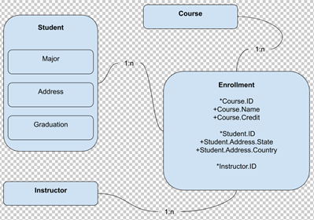

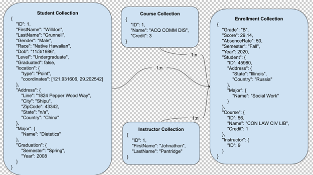

#### Connect to the Database

##### Setup the Database:

Create a database in MongoDB Atlas, get your credentials and connection string.

Ref: https://docs.mongodb.com/manual/introduction/

```python
username = "Jonalex210"
password = "6u3LvaTUPrqz9NL"

mongodb_client = pymongo.MongoClient("mongodb+srv://"+username+":"+password+"@jonathannjeunje-cluster.cgfhy.mongodb.net/UniversityEnrollment?retryWrites=true&w=majority")
```

##### Verify the Connection:

```python
# dir(mongodb_client)
print("Version: " + mongodb_client.server_info()["version"])
```

```
Version: 4.2.11
```

#### Reset Database:

```python
coll_student = mongodb_client.UniversityEnrollment.Student
coll_instructor = mongodb_client.UniversityEnrollment.Instructor
coll_course = mongodb_client.UniversityEnrollment.Course
coll_enrollment = mongodb_client.UniversityEnrollment.Enrollment
```

```python
def reset_mongodb():
    coll_student.delete_many({})
    coll_instructor.delete_many({})
    coll_course.delete_many({})
    coll_enrollment.delete_many({})
```

#### Data Load:

```python
def get_student_info(data, id):
    for record in data:
        if record["ID"] == id:
            return {
                "Address": {
                    "State": record["Address"]["State"],
                    "Country": record["Address"]["Country"]
                },
                "Major": record["Major"]
            }

def get_course_info(data, id):
    for record in data:
        if record["ID"] == id:
            return {
                "Name": record["Name"],
                "Credit": record["Credit"]
            }
```

```python
%%time
UniversityEnrollment_Student = 'dataset/UniversityEnrollment_Student.json'
UniversityEnrollment_Instructor = 'dataset/UniversityEnrollment_Instructor.json'
UniversityEnrollment_Course = 'dataset/UniversityEnrollment_Course.json'
UniversityEnrollment_Enrollment = 'dataset/UniversityEnrollment_Enrollment.json'
UniversityEnrollment_Major = 'dataset/UniversityEnrollment_Major.json'
UniversityEnrollment_Graduation = 'dataset/UniversityEnrollment_Graduation.json'

# Opening JSON file returns JSON object
f = open(UniversityEnrollment_Student,)
data = json.load(f)

coll_student_data = []
for record in data:
    temp = {}
    temp.update(record.pop("Student"))
    temp.update({
        "location": {
          "type": "Point",
          "coordinates": [record["Address"].pop("Longitude"), record["Address"].pop("Latitude")]
        }
    })

    temp.update(record)
    coll_student_data.append(temp)
pprint.pprint(coll_student_data)

# Closing file
f.close()


# Opening JSON file returns JSON object
f = open(UniversityEnrollment_Instructor,)
data = json.load(f)

coll_instructor_data = []
for record in data: coll_instructor_data.append(record["Instructor"])
# pprint.pprint(coll_instructor_data)

# Closing file
f.close()


# Opening JSON file returns JSON object
f = open(UniversityEnrollment_Course,)
data = json.load(f)

coll_course_data = []
for record in data: coll_course_data.append(record["Course"])
# pprint.pprint(coll_course_data)

# Closing file
f.close()


# Opening JSON file returns JSON object
f = open(UniversityEnrollment_Enrollment,)
data = json.load(f)

coll_enrollment_data = []

# Iterating through the json list (batches of data)
for record in data:
    #Built the database collections based on designed schema
    temp = {}
    record["Student"].update(get_student_info(coll_student_data, record["Student"]["ID"]))
    record["Course"].update(get_course_info(coll_course_data, record["Course"]["ID"]))
    temp.update(record.pop("Enrollment"))
    temp.update(record)
    coll_enrollment_data.append(temp)
# pprint.pprint(coll_enrollment_data)

# Closing file
f.close()
```

```
Wall time: 40min 36s
```

```python
print("Records ~", len(coll_student_data) + len(coll_course_data) + len(coll_instructor_data) + len(coll_enrollment_data))
```

```
Records ~ 300467
```

```python
def dataload_mongodb():
    coll_student.insert_many(coll_student_data)
    coll_course.insert_many(coll_course_data)
    coll_instructor.insert_many(coll_instructor_data)
    coll_enrollment.insert_many(coll_enrollment_data)
```

```python
%%time
reset_mongodb()
dataload_mongodb()
```

```
Wall time: 1min 15s
```

### Neo4j

#### The Data Model:

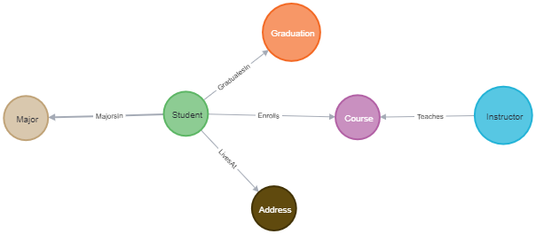

#### Connect to the Database:

##### Setup the Database:

- Create a database in Neo4j Desktop
- Set your password
- The user is by default "neoj4"
- Start your database, and
- Get the uri connection string.

Ref: https://neo4j.com/developer/python/

```python
# Create an instance of the driver object
uri = "bolt://localhost:7687"
username = "neo4j"
password = "UniversityEnrollment"
neo4j_driver = GraphDatabase.driver(uri, auth = (username, password))
```

##### Verify Connection:

```python
print(neo4j_driver.verify_connectivity())
```

```
Neo4j/4.2.1
```

```python
# Create an instance of the session object
neo4j_session = neo4j_driver.session()
```

#### Reset Database:

```python
def reset_neo4j():
    neo4j_session.run("DROP INDEX student_id IF EXISTS");
    neo4j_session.run("DROP INDEX major_name IF EXISTS");
    neo4j_session.run("DROP INDEX instructor_id IF EXISTS");
    neo4j_session.run("DROP INDEX course_id IF EXISTS");
    neo4j_session.run("MATCH (n) DETACH DELETE n;")
```

#### Data Load:

```python
%%time
UniversityEnrollment_Student = 'dataset/UniversityEnrollment_Student.json'
UniversityEnrollment_Instructor = 'dataset/UniversityEnrollment_Instructor.json'
UniversityEnrollment_Course = 'dataset/UniversityEnrollment_Course.json'
UniversityEnrollment_Enrollment = 'dataset/UniversityEnrollment_Enrollment.json'
UniversityEnrollment_Major = 'datasete/UniversityEnrollment_Major.json'
UniversityEnrollment_Graduation = 'dataset/UniversityEnrollment_Graduation.json'

# Opening JSON file returns JSON object
f = open(UniversityEnrollment_Student,)
data = json.load(f)

neo4j_student_data = data
# pprint.pprint(neo4j_student_data)

# Closing file
f.close()


# Opening JSON file returns JSON object
f = open(UniversityEnrollment_Instructor,)
data = json.load(f)

neo4j_instructor_data = data
# pprint.pprint(neo4j_instructor_data)

# Closing file
f.close()


# Opening JSON file returns JSON object
f = open(UniversityEnrollment_Course,)
data = json.load(f)

neo4j_course_data = data
# pprint.pprint(neo4j_student_data)

# Closing file
f.close()


# Opening JSON file returns JSON object
f = open(UniversityEnrollment_Enrollment,)
data = json.load(f)

neo4j_enrollment_data = data
# pprint.pprint(neo4j_enrollment_data)

# Closing file
f.close()
```

```
Wall time: 2.53 s
```

```python
def batches(data, number_of_batches):
# Yield successive n-sized batches from lst."""
    for idx in range(0, len(data), number_of_batches):
        yield data[idx:idx + number_of_batches]
```

```python
def dataload_neo4j():

    neo4j_session.run("CREATE INDEX student_id FOR (n:Student) ON (n.ID)");
#     neo4j_session.run("CREATE INDEX address_id FOR (n:Address) ON (n.ID)");
    neo4j_session.run("CREATE INDEX major_name FOR (n:Major) ON (n.Name)");
    neo4j_session.run("CREATE INDEX instructor_id FOR (n:Instructor) ON (n.ID)");
    neo4j_session.run("CREATE INDEX course_id FOR (n:Course) ON (n.ID)");

    for batch in batches(neo4j_student_data, 50000):
        cypherQP = """
        UNWIND $student_data AS row
        MERGE (std:Student {
                            ID: row.Student.ID,
                            FirstName: row.Student.FirstName,
                            LastName: row.Student.LastName,
                            Gender: row.Student.Gender,
                            Dob: row.Student.Dob,
                            Race: row.Student.Race,
                            Level: row.Student.Level
                            })
        MERGE (adr:Address {
                            Line: row.Address.Line,
                            City: row.Address.City,
                            State: row.Address.State,
                            ZipCode: row.Address.ZipCode,
                            Country: row.Address.Country,
                            Latitude: row.Address.Latitude,
                            Longitude: row.Address.Longitude
                            })
        MERGE (mjr:Major {Name: row.Major.Name})
        MERGE (grd:Graduation {
                                Semester: row.Graduation.Semester,
                                Year: row.Graduation.Year
                                })
        MERGE (std)-[rel1:MajorsIn]->(mjr)
        MERGE (std)-[rel2:LivesAt]->(adr)
        MERGE (std)-[rel3:GraduatesIn {Graduated: row.Student.Graduated}]->(grd)
        """
        neo4j_session.run(cypherQP, parameters={"student_data": batch});
#         break

    cypherQP = """
    UNWIND $instructor_data AS row
    MERGE (ins:Instructor {
                        ID: row.Instructor.ID,
                        FirstName: row.Instructor.FirstName,
                        LastName: row.Instructor.LastName
                        })
    """
    neo4j_session.run(cypherQP, parameters={"instructor_data": neo4j_instructor_data});

    cypherQP = """
    UNWIND $course_data AS row
    MERGE (crs:Course {
                        ID: row.Course.ID,
                        Name: row.Course.Name,
                        Credit: row.Course.Credit
                        })
    """
    neo4j_session.run(cypherQP, parameters={"course_data": neo4j_course_data});

    for batch in batches(neo4j_enrollment_data, 50000):
        cypherQP = """
        UNWIND $enrollment_data AS row
        MATCH (crs:Course {ID: row.Course.ID})
        MATCH (ins:Instructor {ID: row.Instructor.ID})
        MATCH (std:Student {ID: row.Student.ID})
        MERGE (std)-[enl:Enrolls {
                                    AbsenceRate: row.Enrollment.AbsenceRate,
                                    Grade: row.Enrollment.Grade,
                                    Score: row.Enrollment.Score,
                                    Semester: row.Enrollment.Semester,
                                    Year: row.Enrollment.Year
                                    }]->(crs)
        MERGE (ins)-[tea:Teaches {
                                    Semester: row.Enrollment.Semester,
                                    Year: row.Enrollment.Year,
                                    Effectiveness: (.80 * row.Enrollment.Score + .20 * row.Enrollment.AbsenceRate)
                                    }]->(crs)
        """
        neo4j_session.run(cypherQP, parameters={"enrollment_data": batch});
#         break
```

```python
# %%time
reset_neo4j()
dataload_neo4j()
```

### Benchmark Data Load

```python
# Ref: https://www.geeksforgeeks.org/graph-plotting-python-set-1/
# Ref: https://www.geeksforgeeks.org/graph-plotting-python-set-2/
# Ref: https://www.geeksforgeeks.org/graph-plotting-python-set-3/

# Select Plot Style
#plt.style.use('fivethirtyeight')
plt.style.use('ggplot')### Benchmark Data Load:

####################################################################################################
def init_benchmark_data(title):
    benchmark_data = {
        "title": title,
        "label": ["Oracle", "MongoDB", "Neo4j"],
        "runtime": [],
        "result": []
    }
    return benchmark_data

# Ref: https://www.kite.com/python/answers/how-to-round-a-number-to-significant-digits-in-python#:~:text=Use%20round()%20to%20round,)))%20%2D%201)%20.
def round_sig(a_number, significant_digits = 4):
    rounded_number =  round(a_number, significant_digits - int(math.floor(math.log10(abs(a_number)))) - 1)
    return rounded_number

def plot_benchmark_data(benchmark_data):

    # Calculate average
    for runtime in benchmark_data["runtime"]:
        sum = 0
        for val in runtime:
            sum += val
        runtime.append(sum/len(runtime))

    plt.subplots(figsize=(15,5))
    # init position
    pos = np.arange(len(benchmark_data["runtime"][1]))
    barWidth = 0.25

    for idx in range(len(benchmark_data["runtime"])):
        # Set position of bar on X axis
        pos = [x + barWidth for x in pos]
        # Make the plot
        rects = plt.bar(pos, benchmark_data["runtime"][idx], width = barWidth, edgecolor ='white', label = benchmark_data["label"][idx])
        # Ref: https://matplotlib.org/3.3.3/gallery/lines_bars_and_markers/barchart.html#sphx-glr-gallery-lines-bars-and-markers-barchart-py
        """Attach a text label above each bar in *rects*, displaying its height."""
        for rect in rects:
            height = rect.get_height()
            plt.annotate('{}'.format(round_sig(height)),
                        xy=(rect.get_x() + rect.get_width() / 2, height),
                        xytext=(0, 3),  # 3 points vertical offset
                        textcoords="offset points",
                        ha='center', va='bottom')

    # Adding Xticks
    plt.xlabel('Execution', fontweight ='bold')
    plt.ylabel('Runtime in seconds', fontweight ='bold')
    plt.xticks([r + barWidth*2 for r in range(len(benchmark_data["runtime"][1]))], ['first', 'Second', 'Third', 'Average'])
    plt.legend(benchmark_data["label"])
    plt.title(benchmark_data["title"])



    plt.show()
def print_benchmark_data(benchmark_data):
    results = benchmark_data.pop("result")
    runtimes = benchmark_data.pop("runtime")
    label = benchmark_data.pop("label")

    pprint.pprint(benchmark_data)
    print(pds.DataFrame(label))
    print(pds.DataFrame(runtimes))

    data = []
    for result in results: data.append(list(result))
    display = pds.DataFrame(data)
    return display

def benchmark_run(func, num_exe = 3):
    # Collects data for the benchmark
    runtime = []
    for idx in range(num_exe):
        begin = time.time() # store starting time
        result = func()
        end = time.time() # store end time
        runtime.append(end - begin)
    benchmark_data["runtime"].append(runtime)
    benchmark_data["result"].append(result)
####################################################################################################
```

```python
# def test():
#     time.sleep(.1)
#     return [1000]
# ####################################################################################################
# benchmark_data = init_benchmark_data("Data Load")

# benchmark_run(test, 3)
# benchmark_run(test, 3)
# benchmark_run(test, 3)

# plot_benchmark_data(benchmark_data)
# print_benchmark_data(benchmark_data)
# ####################################################################################################
```

```python
# ####################################################################################################
# benchmark_data = init_benchmark_data("Data Load")

# # datadel_oracle()
# # benchmark_run(dataload_oracle, 1)
# # datadel_mongodb()
# # benchmark_run(dataload_mongodb, 1)
# # datadel_neo4j()
# # benchmark_run(dataload_neo4j, 1)

# plot_benchmark_data(benchmark_data)
# print_benchmark_data(benchmark_data)
# ####################################################################################################
```

## Queries Composition and Comparison

#### Query 1 - Which major has the most students retained after the first year?

##### Oracle:

```python
def query_oracle():
    sql = """
        SELECT
            major_name,
            COUNT(student_id) AS "Count_STUDENT_ID"
        FROM
            (
                SELECT DISTINCT
                    COUNT(DISTINCT enrollment.year) AS "count_year",
                    enrollment.student_id,
                    student.major_name
                FROM
                         enrollment
                    INNER JOIN student ON student.id = enrollment.student_id
                GROUP BY
                    enrollment.student_id,
                    student.major_name
                HAVING
                    COUNT(DISTINCT enrollment.year) > 1
            )
        GROUP BY
            major_name
        ORDER BY
            "Count_STUDENT_ID" DESC
        FETCH FIRST 5 ROWS ONLY
    """
    result = oracle_cursor.execute(sql)
    return result
# print(list(query_oracle()))
```

##### MongoDB:

```python
def query_mongodb():
    result = coll_enrollment.aggregate([
        {
            '$group': {
                '_id': {
                    'major': '$Student.Major.Name',
                    'student': '$Student.ID'
                },
                'years': {
                    '$addToSet': '$Year'
                }
            }
        }, {
            '$project': {
                'count_years': {
                    '$size': '$years'
                }
            }
        }, {
            '$match': {
                'count_years': {
                    '$gte': 2
                }
            }
        }, {
            '$group': {
                '_id': {
                    'major': '$_id.major'
                },
                'count_student': {
                    '$sum': 1
                }
            }
        }, {
            '$sort': {
                'count_student': -1
            }
        }, {
            '$limit': 5
        }
    ])
    return result
# print(list(query_mongodb()))
```

##### Neo4j:

```python
def query_neo4j():
    cypherQ = """
        MATCH (mjr:Major)<-[mjn:MajorsIn]-(std:Student)-[enr:Enrolls]->(crs:Course)
        WITH mjr, std, collect(DISTINCT enr.Year) as years
        WHERE size(years) > 1
        WITH mjr, count(std) AS student_count
        ORDER BY student_count DESC
        RETURN mjr.Name, student_count
        LIMIT 5
    """
    result = neo4j_session.run(cypherQ)
    return result
# pprint.pprint(list(query_neo4j()))
```

##### Comparison:

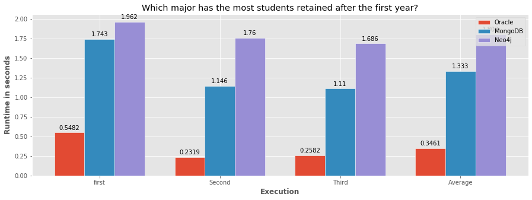

```
{'title': 'Which major has the most students retained after the first year?'}
         0
0  Oracle
1  MongoDB
2  Neo4j
          0         1         2         3
0  0.548161  0.231867  0.258194  0.346074
1  1.743407  1.146028  1.109854  1.333096
2  1.962085  1.759998  1.685862  1.802648
```

|  | 0 | 1 | 2 | 3 | 4 |
| --- | --- | --- | --- | --- | --- |
| 0 | (Spanish Education, 1998) | (Athletic Training, 1944) | (Philosophy, 1941) | (Elementary Education, 1928) | (Physical Education, 1925) |
| 1 | {'_id': {'major': 'Spanish Education'}, 'count_student': 1998} | {'_id': {'major': 'Athletic Training'}, 'count_student': 1944} | {'_id': {'major': 'Philosophy'}, 'count_student': 1941} | {'_id': {'major': 'Elementary Education'}, 'count_student': 1928} | {'_id': {'major': 'Physical Education'}, 'count_student': 1925} |
| 2 | (Spanish Education, 1998) | (Athletic Training, 1944) | (Philosophy, 1941) | (Elementary Education, 1928) | (Physical Education, 1925) |

```python
####################################################################################################
benchmark_data = init_benchmark_data("Which major has the most students retained after the first year?")

benchmark_run(query_oracle)
benchmark_run(query_mongodb)
benchmark_run(query_neo4j)

plot_benchmark_data(benchmark_data)
print_benchmark_data(benchmark_data)
####################################################################################################
```

#### Query 2 - What course has the highest percent of people with grade W?

##### Oracle:

```python
def query_oracle():
    sql = """
SELECT
    course.name,
    ( COUNT(DISTINCT enrollment.student_id) / (
        SELECT
            COUNT(DISTINCT enrollment.student_id) AS "total"
        FROM
                 enrollment
            INNER JOIN course ON enrollment.course_id = course.id
        WHERE
            enrollment.grade LIKE 'W'
    ) ) * 100 AS "percentage"
FROM
         enrollment
    INNER JOIN course ON enrollment.course_id = course.id
WHERE
    enrollment.grade LIKE 'W'
GROUP BY
    course.name
ORDER BY
    "percentage" DESC
FETCH FIRST 5 ROWS ONLY
    """
    result = oracle_cursor.execute(sql)
    return result
```

##### MongoDB:

```python
def query_mongodb():
    result = coll_enrollment.aggregate([
    {
        '$match': {
            'Grade': {
                '$eq': 'W'
            }
        }
    }, {
        '$facet': {
            'courses': [
                {
                    '$group': {
                        '_id': {
                            'course': '$Course.Name'
                        },
                        'count': {
                            '$sum': 1
                        }
                    }
                }, {
                    '$sort': {
                        'count': -1
                    }
                }, {
                    '$limit': 5
                }
            ],
            'totals': [
                {
                    '$group': {
                        '_id': None,
                        'total': {
                            '$sum': 1
                        }
                    }
                }
            ]
        }
    }, {
        '$project': {
            'courses': 1,
            'total': {
                '$arrayElemAt': [
                    '$totals', 0
                ]
            }
        }
    }, {
        '$project': {
            'courses': {
                '$map': {
                    'input': '$courses',
                    'as': 'course',
                    'in': [
                        {
                            'state': '$$course._id.course'
                        }, {
                            'percentage': {
                                '$multiply': [
                                    {
                                        '$divide': [
                                            '$$course.count', '$total.total'
                                        ]
                                    }, 100
                                ]
                            }
                        }
                    ]
                }
            }
        }
    }
])
    return result
```

##### Neo4j:

```python
def query_neo4j():
    cypherQ = """
        MATCH path = (std:Student)-[enr:Enrolls {Grade:"W"}]->(crs:Course)
        WITH count(path) AS total

        MATCH path = (std:Student)-[enr:Enrolls {Grade:"W"}]->(crs:Course)
        WITH crs, total, count(path) AS count
        ORDER BY count DESC
        LIMIT 5

        RETURN crs.Name, (toFloat(count)/total)*100 AS percentage
    """
    result = neo4j_session.run(cypherQ)
    return result
```

##### Comparison:

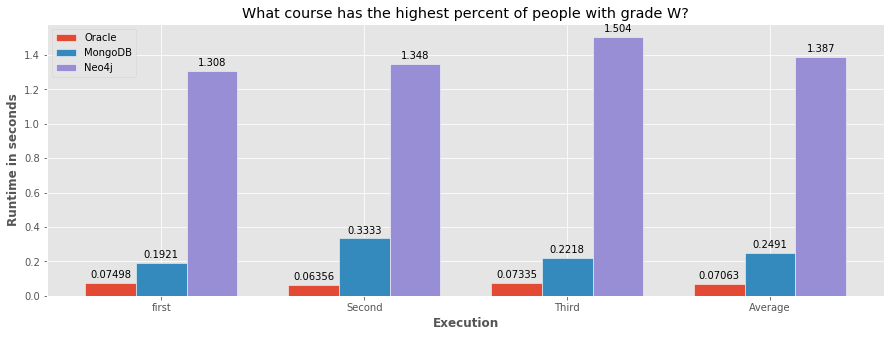

```
{'title': 'What course has the highest percent of people with grade W?'}
         0
0  Oracle
1  MongoDB
2  Neo4j
          0         1         2         3
0  0.074977  0.063559  0.073347  0.070628
1  0.192114  0.333345  0.221769  0.249076
2  1.308122  1.347869  1.504276  1.386756
```

|  | 0 | 1 | 2 | 3 | 4 |
| --- | --- | --- | --- | --- | --- |
| 0 | (CLIN ASSESS II, 0.5625935969563282) | (NUM ALG GEO T&L, 0.5504512891083498) | (AGRI FINANCE, 0.5383089812603715) | (SERV PROD MKTG, 0.5261666734123932) | (INT HUMAN COMM, 0.518071801513741) |
| 1 | {'courses': [[{'state': 'CLIN ASSESS II'}, {'percentage': 0.48693337069992293}], [{'state': 'NUM ALG GEO T&L'}, {'percentage': 0.47642401737546414}], [{'state': 'AGRI FINANCE'}, {'percentage': 0.46941… | None | None | None | None |
| 2 | (CLIN ASSESS II, 0.48693337069992293) | (NUM ALG GEO T&L, 0.47642401737546414) | (AGRI FINANCE, 0.469417781825825) | (SERV PROD MKTG, 0.4554053107265466) | (INT HUMAN COMM, 0.4483990751769074) |

```python
####################################################################################################
benchmark_data = init_benchmark_data("What course has the highest percent of people with grade W?")

benchmark_run(query_oracle)
benchmark_run(query_mongodb)
benchmark_run(query_neo4j)

plot_benchmark_data(benchmark_data)
print_benchmark_data(benchmark_data)
####################################################################################################
```

#### Query 3 - What’s a 4-year graduation rate among the female students, grouped by majors?

##### Oracle:

```python
def query_oracle():
    sql = """
SELECT
    student.major_name,
    COUNT(student.id) AS "Count_ID"
FROM
    student
WHERE
    student.gender LIKE 'Female'
    AND student.year BETWEEN ( 2020 - 3 ) AND 2020
    AND student.graduated LIKE '1'
GROUP BY
    student.major_name
ORDER BY
    "Count_ID" DESC

    """
    result = oracle_cursor.execute(sql)
    return result
```

##### MongoDB:

```python
def query_mongodb():
    result = coll_student.aggregate([
    {
        '$match': {
            'Gender': 'Female',
            'Graduated': True
        }
    }, {
        '$project': {
            'Graduation': 1,
            'Major': 1,
            'match': {
                '$in': [
                    '$Graduation.Year', {
                        '$range': [
                            2020 - 3, 2020, 1
                        ]
                    }
                ]
            }
        }
    }, {
        '$match': {
            'match': True
        }
    }, {
        '$group': {
            '_id': {
                'major': '$Major.Name'
            },
            'count_student': {
                '$sum': 1
            }
        }
    }, {
        '$sort': {
            'count_student': -1
        }
    }
])
    return result
```

##### Neo4j:

```python
def query_neo4j():
    cypherQ = """
        WITH 2020 AS late_grd_year
        MATCH (grd:Graduation)
        WHERE grd.Year IN range(late_grd_year-3, late_grd_year, 1)
        MATCH (mjr:Major)<-[mjn:MajorsIn]-(std:Student {Gender: "Female"})-[grn:GraduatesIn {Graduated: true}]->(grd)
        WITH mjr.Name AS major, count(std) AS student_count
        ORDER BY student_count DESC
        RETURN major, student_count
    """
    result = neo4j_session.run(cypherQ)
    return result
```

##### Comparison:

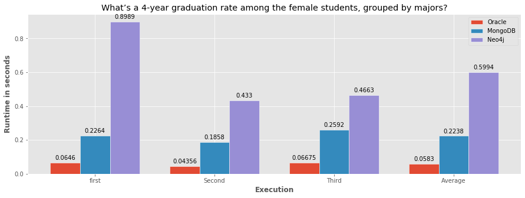

```
{'title': 'What’s a 4-year graduation rate among the female students, grouped '
          'by majors?'}
         0
0  Oracle
1  MongoDB
2  Neo4j
          0         1         2         3
0  0.064601  0.043560  0.066747  0.058302
1  0.226381  0.185796  0.259163  0.223780
2  0.898915  0.432986  0.466252  0.599384
```

|  | 0 | 1 | 2 | 3 | 4 | 5 | 6 | 7 | 8 | 9 | ... | 20 | 21 | 22 | 23 | 24 | 25 | 26 | 27 | 28 | 29 |
| --- | --- | --- | --- | --- | --- | --- | --- | --- | --- | --- | --- | --- | --- | --- | --- | --- | --- | --- | --- | --- | --- |
| 0 | (Middle Level Education, 196) | (Physical Education, 192) | (History, 187) | (Spanish Education, 186) | (Dietetics, 183) | (Philosophy, 180) | (Exercise Science, 179) | (Health sciences, 178) | (Nursing, 176) | (Chemistry, 176) | ... | (Mathematics, 159) | (English, 158) | (Public Health, 154) | (Womens Studies, 154) | (Sociology, 154) | (Special Education, 153) | (Emergency Management, 152) | (Computer science, 150) | (Engineering, 145) | (Physics, 133) |
| 1 | {'_id': {'major': 'Physical Education'}, 'count_student': 160} | {'_id': {'major': 'Middle Level Education'}, 'count_student': 155} | {'_id': {'major': 'Information technology'}, 'count_student': 142} | {'_id': {'major': 'Exercise Science'}, 'count_student': 141} | {'_id': {'major': 'Spanish Education'}, 'count_student': 139} | {'_id': {'major': 'Biology'}, 'count_student': 138} | {'_id': {'major': 'History'}, 'count_student': 134} | {'_id': {'major': 'French Education'}, 'count_student': 134} | {'_id': {'major': 'Social Work'}, 'count_student': 133} | {'_id': {'major': 'Dietetics'}, 'count_student': 133} | ... | {'_id': {'major': 'Psychology'}, 'count_student': 120} | {'_id': {'major': 'Emergency Management'}, 'count_student': 118} | {'_id': {'major': 'Public Health'}, 'count_student': 117} | {'_id': {'major': 'Computer science'}, 'count_student': 117} | {'_id': {'major': 'Sociology'}, 'count_student': 117} | {'_id': {'major': 'English'}, 'count_student': 117} | {'_id': {'major': 'Mathematics'}, 'count_student': 112} | {'_id': {'major': 'Engineering'}, 'count_student': 106} | {'_id': {'major': 'Special Education'}, 'count_student': 106} | {'_id': {'major': 'Physics'}, 'count_student': 95} |
| 2 | (Middle Level Education, 196) | (Physical Education, 192) | (History, 187) | (Spanish Education, 186) | (Dietetics, 183) | (Philosophy, 180) | (Exercise Science, 179) | (Health sciences, 178) | (Chemistry, 176) | (Nursing, 176) | ... | (Hospitality Management, 159) | (English, 158) | (Public Health, 154) | (Sociology, 154) | (Womens Studies, 154) | (Special Education, 153) | (Emergency Management, 152) | (Computer science, 150) | (Engineering, 145) | (Physics, 133) |

3 rows × 30 columns

```python
####################################################################################################
benchmark_data = init_benchmark_data("What’s a 4-year graduation rate among the female students, grouped by majors?")

benchmark_run(query_oracle)
benchmark_run(query_mongodb)
benchmark_run(query_neo4j)

plot_benchmark_data(benchmark_data)
print_benchmark_data(benchmark_data)
####################################################################################################
```

#### Query 4 - Rank all courses in terms of their popularity (cumulated number enrollments).

##### Oracle:

```python
def query_oracle():
    sql = """
SELECT
    course.name,
    COUNT(*) AS "Count_Enrollments"
FROM
         course
    INNER JOIN enrollment ON course.id = enrollment.course_id
GROUP BY
    course.name
ORDER BY
    "Count_Enrollments" DESC

    """
    result = oracle_cursor.execute(sql)
    return result
```

##### MongoDB:

```python
def query_mongodb():
    result = coll_enrollment.aggregate([
    {
        '$group': {
            '_id': {
                'course': '$Course.Name'
            },
            'count_enrollment': {
                '$sum': 1
            }
        }
    }, {
        '$sort': {
            'count_enrollment': -1
        }
    }
])

    return result
```

##### Neo4j:

```python
def query_neo4j():
    cypherQ = """
        MATCH (std:Student)-[enr:Enrolls]->(crs:Course)
WITH crs.Name AS name_crs, count(enr) As num_enr
ORDER BY num_enr DESC
RETURN name_crs, num_enr

    """
    result = neo4j_session.run(cypherQ)
    return result
```

##### Comparison:

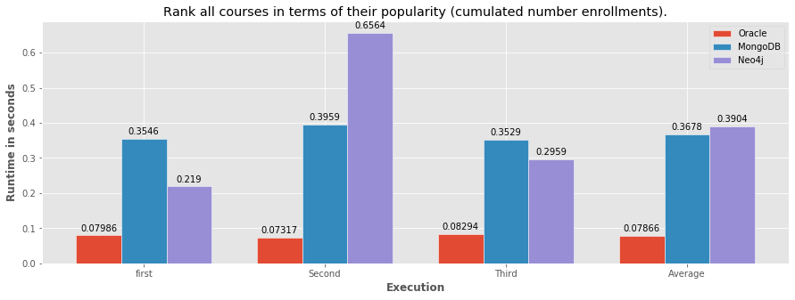

```
{'title': 'Rank all courses in terms of their popularity (cumulated number '
          'enrollments).'}
         0
0  Oracle
1  MongoDB
2  Neo4j
          0         1         2         3
0  0.079857  0.073166  0.082944  0.078656
1  0.354577  0.395923  0.352933  0.367811
2  0.218989  0.656381  0.295936  0.390435
```

|  | 0 | 1 | 2 | 3 | 4 | 5 | 6 | 7 | 8 | 9 | ... | 257 | 258 | 259 | 260 | 261 | 262 | 263 | 264 | 265 | 266 |
| --- | --- | --- | --- | --- | --- | --- | --- | --- | --- | --- | --- | --- | --- | --- | --- | --- | --- | --- | --- | --- | --- |
| 0 | (CLIN ASSESS II, 828) | (UNIV PHYS II, 826) | (STRUCTURAL GEOL, 820) | (SYNOPTIC MET II, 814) | (CALC AN GEOM II, 807) | (THEORY II, 804) | (PERCUSSION TECH, 802) | (CLINICAL PSY, 802) | (FIN HEALTH, 802) | (INTEG SCI II, 800) | ... | (DATA STRUCT II, 701) | (SCI THINK CSD, 701) | (DRAWING I, 700) | (SHEEP SCIENCE, 700) | (EVAL PRO S/L PA, 698) | (APPL PHYS LAB, 697) | (URBAN FOR MGT, 695) | (DYSPHAGIA, 692) | (COMP GRAPHICS, 688) | (PAINTING 2 & 3, 637) |
| 1 | {'_id': {'course': 'CLIN ASSESS II'}, 'count_enrollment': 828} | {'_id': {'course': 'UNIV PHYS II'}, 'count_enrollment': 826} | {'_id': {'course': 'STRUCTURAL GEOL'}, 'count_enrollment': 820} | {'_id': {'course': 'SYNOPTIC MET II'}, 'count_enrollment': 814} | {'_id': {'course': 'CALC AN GEOM II'}, 'count_enrollment': 807} | {'_id': {'course': 'THEORY II'}, 'count_enrollment': 804} | {'_id': {'course': 'PERCUSSION TECH'}, 'count_enrollment': 802} | {'_id': {'course': 'FIN HEALTH'}, 'count_enrollment': 802} | {'_id': {'course': 'CLINICAL PSY'}, 'count_enrollment': 802} | {'_id': {'course': 'INTEG SCI II'}, 'count_enrollment': 800} | ... | {'_id': {'course': 'SCI THINK CSD'}, 'count_enrollment': 701} | {'_id': {'course': 'DATA STRUCT II'}, 'count_enrollment': 701} | {'_id': {'course': 'SHEEP SCIENCE'}, 'count_enrollment': 700} | {'_id': {'course': 'DRAWING I'}, 'count_enrollment': 700} | {'_id': {'course': 'EVAL PRO S/L PA'}, 'count_enrollment': 698} | {'_id': {'course': 'APPL PHYS LAB'}, 'count_enrollment': 697} | {'_id': {'course': 'URBAN FOR MGT'}, 'count_enrollment': 695} | {'_id': {'course': 'DYSPHAGIA'}, 'count_enrollment': 692} | {'_id': {'course': 'COMP GRAPHICS'}, 'count_enrollment': 688} | {'_id': {'course': 'PAINTING 2 & 3'}, 'count_enrollment': 637} |
| 2 | (CLIN ASSESS II, 828) | (UNIV PHYS II, 826) | (STRUCTURAL GEOL, 820) | (SYNOPTIC MET II, 814) | (CALC AN GEOM II, 807) | (THEORY II, 804) | (CLINICAL PSY, 802) | (FIN HEALTH, 802) | (PERCUSSION TECH, 802) | (INTEG SCI II, 800) | ... | (DATA STRUCT II, 701) | (SCI THINK CSD, 701) | (DRAWING I, 700) | (SHEEP SCIENCE, 700) | (EVAL PRO S/L PA, 698) | (APPL PHYS LAB, 697) | (URBAN FOR MGT, 695) | (DYSPHAGIA, 692) | (COMP GRAPHICS, 688) | (PAINTING 2 & 3, 637) |

3 rows × 267 columns

```python
####################################################################################################
benchmark_data = init_benchmark_data("Rank all courses in terms of their popularity (cumulated number enrollments).")

benchmark_run(query_oracle)
benchmark_run(query_mongodb)
benchmark_run(query_neo4j)

plot_benchmark_data(benchmark_data)
print_benchmark_data(benchmark_data)
####################################################################################################
```

#### Query 5 - What is the trend of enrollment over the years?

##### Oracle:

```python
def query_oracle():
    sql = """
SELECT
    COUNT(*) AS "Count_Enrollments",
    enrollment.year
FROM
    enrollment
GROUP BY
    enrollment.year
ORDER BY
    "Count_Enrollments" DESC

    """
    result = oracle_cursor.execute(sql)
    return result
```

##### MongoDB:

```python
def query_mongodb():
    result = coll_enrollment.aggregate([
    {
        '$group': {
            '_id': {
                'year': '$Year'
            },
            'count_enrollment': {
                '$sum': 1
            }
        }
    }, {
        '$sort': {
            'count_enrollment': -1
        }
    }
])

    return result
```

##### Neo4j:

```python
def query_neo4j():
    cypherQ = """
        MATCH (std:Student)-[enr:Enrolls]->(crs:Course)
With enr.Year as year, count(enr) AS enr_count
ORDER BY enr_count DESC
RETURN year, enr_count

    """
    result = neo4j_session.run(cypherQ)
    return result
```

##### Comparison:

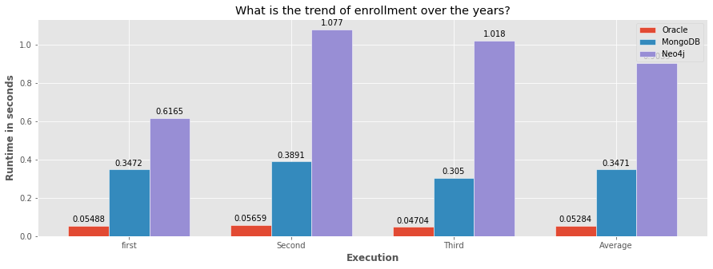

```
{'title': 'What is the trend of enrollment over the years?'}
         0
0  Oracle
1  MongoDB
2  Neo4j
          0         1         2         3
0  0.054877  0.056593  0.047038  0.052836
1  0.347185  0.389113  0.304992  0.347097
2  0.616533  1.077328  1.017729  0.903863
```

|  | 0 | 1 | 2 | 3 | 4 | 5 | 6 | 7 | 8 | 9 | ... | 11 | 12 | 13 | 14 | 15 | 16 | 17 | 18 | 19 | 20 |
| --- | --- | --- | --- | --- | --- | --- | --- | --- | --- | --- | --- | --- | --- | --- | --- | --- | --- | --- | --- | --- | --- |
| 0 | (10106, 2013) | (10085, 2012) | (10034, 2020) | (10019, 2019) | (10013, 2014) | (9942, 2010) | (9936, 2018) | (9913, 2017) | (9894, 2016) | (9888, 2011) | ... | (9172, 2009) | (9154, 2003) | (9141, 2008) | (9102, 2002) | (9076, 2004) | (9074, 2007) | (9023, 2000) | (8996, 2006) | (8987, 2005) | (8789, 2001) |
| 1 | {'_id': {'year': 2013}, 'count_enrollment': 10106} | {'_id': {'year': 2012}, 'count_enrollment': 10085} | {'_id': {'year': 2020}, 'count_enrollment': 10034} | {'_id': {'year': 2019}, 'count_enrollment': 10019} | {'_id': {'year': 2014}, 'count_enrollment': 10013} | {'_id': {'year': 2010}, 'count_enrollment': 9942} | {'_id': {'year': 2018}, 'count_enrollment': 9936} | {'_id': {'year': 2017}, 'count_enrollment': 9913} | {'_id': {'year': 2016}, 'count_enrollment': 9894} | {'_id': {'year': 2011}, 'count_enrollment': 9888} | ... | {'_id': {'year': 2009}, 'count_enrollment': 9172} | {'_id': {'year': 2003}, 'count_enrollment': 9154} | {'_id': {'year': 2008}, 'count_enrollment': 9141} | {'_id': {'year': 2002}, 'count_enrollment': 9102} | {'_id': {'year': 2004}, 'count_enrollment': 9076} | {'_id': {'year': 2007}, 'count_enrollment': 9074} | {'_id': {'year': 2000}, 'count_enrollment': 9023} | {'_id': {'year': 2006}, 'count_enrollment': 8996} | {'_id': {'year': 2005}, 'count_enrollment': 8987} | {'_id': {'year': 2001}, 'count_enrollment': 8789} |
| 2 | (2013, 10106) | (2012, 10085) | (2020, 10034) | (2019, 10019) | (2014, 10013) | (2010, 9942) | (2018, 9936) | (2017, 9913) | (2016, 9894) | (2011, 9888) | ... | (2009, 9172) | (2003, 9154) | (2008, 9141) | (2002, 9102) | (2004, 9076) | (2007, 9074) | (2000, 9023) | (2006, 8996) | (2005, 8987) | (2001, 8789) |

3 rows × 21 columns

```python
####################################################################################################
benchmark_data = init_benchmark_data("What is the trend of enrollment over the years?")

benchmark_run(query_oracle)
benchmark_run(query_mongodb)
benchmark_run(query_neo4j)

plot_benchmark_data(benchmark_data)
print_benchmark_data(benchmark_data)
####################################################################################################
```

#### Query 6 - How does the number of full-time students vs part-time students compare for both graduate and undergraduate students?

##### Oracle:

```python
def query_oracle():
    sql = """
SELECT
    'Full-time'             AS type,
    gradlevel,
    COUNT("Sum_CREDIT")     AS "Count_Sum_CREDIT"
FROM
    (
        SELECT
            student.id,
            SUM(course.credit) AS "Sum_CREDIT",
            student.gradlevel
        FROM
                 student
            INNER JOIN enrollment ON student.id = enrollment.student_id
            INNER JOIN course ON enrollment.course_id = course.id
        WHERE
                enrollment.year = 2020
            AND enrollment.semester LIKE 'Spring'
        GROUP BY
            student.id,
            student.gradlevel
        HAVING
            SUM(course.credit) >= 9
    )
GROUP BY
    'Full-time',
    gradlevel
UNION
SELECT
    'Part-time'             AS type,
    gradlevel,
    COUNT("Sum_CREDIT")     AS "Count_Sum_CREDIT"
FROM
    (
        SELECT
            student.id,
            SUM(course.credit) AS "Sum_CREDIT",
            student.gradlevel
        FROM
                 student
            INNER JOIN enrollment ON student.id = enrollment.student_id
            INNER JOIN course ON enrollment.course_id = course.id
        WHERE
                enrollment.year = 2020
            AND enrollment.semester LIKE 'Spring'
        GROUP BY
            student.id,
            student.gradlevel
        HAVING
            SUM(course.credit) < 9
    )
GROUP BY
    'Part-time',
    gradlevel

    """
    result = oracle_cursor.execute(sql)
    return result
```

##### MongoDB:

```python
def query_mongodb():
    result = coll_enrollment.aggregate([
    {
        '$match': {
            'Year': 2020,
            'Semester': 'Spring'
        }
    }, {
        '$group': {
            '_id': '$Student.ID',
            'total_credit': {
                '$sum': '$Course.Credit'
            }
        }
    }, {
        '$facet': {
            'full_time': [
                {
                    '$match': {
                        'total_credit': {
                            '$gte': 9
                        }
                    }
                }, {
                    '$lookup': {
                        'from': 'Student',
                        'localField': '_id',
                        'foreignField': 'ID',
                        'as': 'student'
                    }
                }, {
                    '$project': {
                        'type': 'Full-time',
                        'total_creddit': 1,
                        'student': {
                            '$arrayElemAt': [
                                '$student', 0
                            ]
                        }
                    }
                }, {
                    '$group': {
                        '_id': {
                            'level': '$student.Level'
                        },
                        'count_student': {
                            '$sum': 1
                        }
                    }
                }
            ],
            'part_time': [
                {
                    '$match': {
                        'total_credit': {
                            '$lt': 9
                        }
                    }
                }, {
                    '$lookup': {
                        'from': 'Student',
                        'localField': '_id',
                        'foreignField': 'ID',
                        'as': 'student'
                    }
                }, {
                    '$project': {
                        'type': 'Full-time',
                        'total_creddit': 1,
                        'student': {
                            '$arrayElemAt': [
                                '$student', 0
                            ]
                        }
                    }
                }, {
                    '$group': {
                        '_id': {
                            'level': '$student.Level'
                        },
                        'count_student': {
                            '$sum': 1
                        }
                    }
                }
            ]
        }
    }
])

    return result
```

##### Neo4j:

```python
def query_neo4j():
    cypherQ = """
        WITH 2020 AS enr_year, 'Spring' AS enr_semester
        MATCH (std:Student)-[enr:Enrolls {Year: enr_year, Semester: enr_semester}]->(crs:Course)
        WITH std, sum(crs.Credit) AS total_credit
        WHERE total_credit >= 9
        WITH std.Level AS student_level, count(*) AS student_count
        RETURN "Full-time" AS type, student_level, student_count
    """
    result = neo4j_session.run(cypherQ)

    cypherQ = """
        WITH 2020 AS enr_year, 'Spring' AS enr_semester
        MATCH (std:Student)-[enr:Enrolls {Year: enr_year, Semester: enr_semester}]->(crs:Course)
        WITH std, sum(crs.Credit) AS total_credit
        WHERE total_credit < 9
        WITH std.Level AS student_level, count(*) AS student_count
        RETURN "Part-time" AS type, student_level, student_count
    """
    result = neo4j_session.run(cypherQ)
    return result
```

##### Comparison:

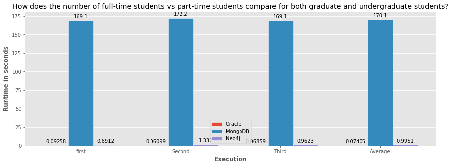

```
{'title': 'How does the number of full-time students vs part-time students '
          'compare for both graduate and undergraduate students?'}
         0
0  Oracle
1  MongoDB
2  Neo4j
            0           1           2           3
0  0.092578    0.060987    0.068591    0.074052
1  169.069020  172.194228  169.139583  170.134277
2  0.691152    1.331744    0.962342    0.995079
```

|  | 0 | 1 | 2 | 3 |
| --- | --- | --- | --- | --- |
| 0 | (Full-time, Graduate, 4) | (Full-time, Undergraduate, 5) | (Part-time, Graduate, 1601) | (Part-time, Undergraduate, 1692) |
| 1 | {'full_time': [{'_id': {'level': 'Undergraduate'}, 'count_student': 5}, {'_id': {'level': 'Graduate'}, 'count_student': 4}], 'part_time': [{'_id': {'level': 'Graduate'}, 'count_student': 1601}, {'_id'… | None | None | None |
| 2 | (Part-time, Graduate, 1601) | (Part-time, Undergraduate, 1692) | None | None |

```python
####################################################################################################
benchmark_data = init_benchmark_data("How does the number of full-time students vs part-time students compare for both graduate and undergraduate students?")

benchmark_run(query_oracle)
benchmark_run(query_mongodb)
benchmark_run(query_neo4j)

plot_benchmark_data(benchmark_data)
print_benchmark_data(benchmark_data)
####################################################################################################
```

#### Query 7 - What are the percentages of female vs male students in STEM programs?

##### Oracle:

```python
def query_oracle():
    sql = """
SELECT
    student.gender,
    (COUNT(student.id) / (
        SELECT
            COUNT(student.id) AS "total"
        FROM
            student
        WHERE
            student.major_name IN (
                'Astronomy',
                'Biology',
                'Chemistry',
                'Computer science',
                'Engineering',
                'Earth sciences',
                'Health sciences',
                'Information technology',
                'Mathematics',
                'Physics'
            )
    ))*100 AS "percentage"
FROM
    student
WHERE
    student.major_name IN (
        'Astronomy',
        'Biology',
        'Chemistry',
        'Computer science',
        'Engineering',
        'Earth sciences',
        'Health sciences',
        'Information technology',
        'Mathematics',
        'Physics'
    )
GROUP BY
    student.gender

    """
    result = oracle_cursor.execute(sql)
    return result
```

##### MongoDB:

```python
def query_mongodb():
    result = coll_student.aggregate([
    {
        '$project': {
            'Gender': 1,
            'stem': {
                '$in': [
                    '$Major.Name', [
                        'Astronomy', 'Biology', 'Chemistry', 'Computer science', 'Engineering', 'Earth sciences', 'Health sciences', 'Information technology', 'Mathematics', 'Physics'
                    ]
                ]
            }
        }
    }, {
        '$match': {
            'stem': True
        }
    }, {
        '$facet': {
            'genders': [
                {
                    '$group': {
                        '_id': {
                            'gender': '$Gender'
                        },
                        'count_student': {
                            '$sum': 1
                        }
                    }
                }
            ],
            'total': [
                {
                    '$group': {
                        '_id': None,
                        'total': {
                            '$sum': 1
                        }
                    }
                }
            ]
        }
    }, {
        '$project': {
            'gender1': {
                '$arrayElemAt': [
                    '$genders', 0
                ]
            },
            'gender2': {
                '$arrayElemAt': [
                    '$genders', 1
                ]
            },
            'total': {
                '$arrayElemAt': [
                    '$total', 0
                ]
            }
        }
    }, {
        '$project': {
            'result': [
                {
                    'gender': '$gender1._id.gender',
                    'percentage': {
                        '$multiply': [
                            {
                                '$divide': [
                                    '$gender1.count_student', '$total.total'
                                ]
                            }, 100
                        ]
                    }
                }, {
                    'gender': '$gender2._id.gender',
                    'percentage': {
                        '$multiply': [
                            {
                                '$divide': [
                                    '$gender2.count_student', '$total.total'
                                ]
                            }, 100
                        ]
                    }
                }
            ]
        }
    }
])

    return result
```

##### Neo4j:

```python
def query_neo4j():
    cypherQ = """
        WITH ["Astronomy","Biology","Chemistry","Computer science","Engineering","Earth sciences","Health sciences","Information technology","Mathematics","Physics"
] AS stem_majors
MATCH (mjr:Major)
WHERE mjr.Name IN stem_majors

MATCH (std:Student)-[mjn:MajorsIn]->(mjr)
WITH count(std) AS total

WITH ["Astronomy","Biology","Chemistry","Computer science","Engineering","Earth sciences","Health sciences","Information technology","Mathematics","Physics"
] AS stem_majors, total
MATCH (mjr:Major)
WHERE mjr.Name IN stem_majors

MATCH (std:Student)-[mjn:MajorsIn]->(mjr)
WITH std.Gender AS student_gender, (toFloat(count(std))/total)*100 AS percentage

RETURN student_gender, percentage
    """
    result = neo4j_session.run(cypherQ)
    return result
```

##### Comparison:

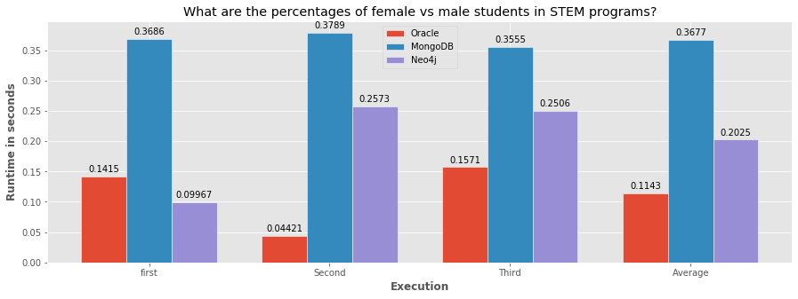

```
{'title': 'What are the percentages of female vs male students in STEM '
          'programs?'}
         0
0  Oracle
1  MongoDB
2  Neo4j
          0         1         2         3
0  0.141470  0.044206  0.157077  0.114251
1  0.368642  0.378913  0.355508  0.367688
2  0.099666  0.257316  0.250568  0.202517
```

|  | 0 | 1 |
| --- | --- | --- |
| 0 | (Male, 49.903649283391545) | (Female, 50.096350716608455) |
| 1 | {'result': [{'gender': 'Female', 'percentage': 50.09635071660845}, {'gender': 'Male', 'percentage': 49.903649283391545}]} | None |
| 2 | (Male, 49.903649283391545) | (Female, 50.09635071660845) |

```python
####################################################################################################
benchmark_data = init_benchmark_data("What are the percentages of female vs male students in STEM programs?")

benchmark_run(query_oracle)
benchmark_run(query_mongodb)
benchmark_run(query_neo4j)

plot_benchmark_data(benchmark_data)
print_benchmark_data(benchmark_data)
####################################################################################################
```

#### Query 8 - What is the distribution of students with respect to their race?

##### Oracle:

```python
def query_oracle():
    sql = """
SELECT
    student.race,
    ( COUNT(student.id) / (
        SELECT
            COUNT(student.id) AS "total"
        FROM
            student
    ) ) * 100 AS "percentage"
FROM
    student
GROUP BY
    student.race
ORDER BY
    "percentage" DESC

    """
    result = oracle_cursor.execute(sql)
    return result
```

##### MongoDB:

```python
def query_mongodb():
    result = coll_student.aggregate([
    {
        '$facet': {
            'races': [
                {
                    '$group': {
                        '_id': {
                            'race': '$Race'
                        },
                        'count_student': {
                            '$sum': 1
                        }
                    }
                }
            ],
            'total': [
                {
                    '$group': {
                        '_id': None,
                        'total': {
                            '$sum': 1
                        }
                    }
                }, {
                    '$project': {
                        '_id': 0,
                        'total': 1
                    }
                }
            ]
        }
    }, {
        '$project': {
            'races': 1,
            'total': {
                '$arrayElemAt': [
                    '$total', 0
                ]
            }
        }
    }, {
        '$project': {
            'races': {
                '$map': {
                    'input': '$races',
                    'as': 'race',
                    'in': [
                        {
                            'race': '$$race._id.race'
                        }, {
                            'percentage': {
                                '$multiply': [
                                    {
                                        '$divide': [
                                            '$$race.count_student', '$total.total'
                                        ]
                                    }, 100
                                ]
                            }
                        }
                    ]
                }
            }
        }
    }
])

    return result
```

##### Neo4j:

```python
def query_neo4j():
    cypherQ = """
        MATCH (std: Student)
WITH count(*) AS total
MATCH (std: Student)
WITH std.Race as race, (toFloat(count(std))/total)*100 AS per
ORDER BY per DESC
RETURN race, per

    """
    result = neo4j_session.run(cypherQ)
    return result
```

##### Comparison:

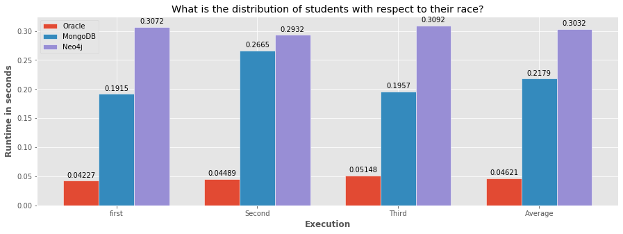

```
{'title': 'What is the distribution of students with respect to their race?'}
         0
0  Oracle
1  MongoDB
2  Neo4j
          0         1         2         3
0  0.042268  0.044887  0.051484  0.046213
1  0.191484  0.266478  0.195736  0.217899
2  0.307173  0.293214  0.309173  0.303187
```

|  | 0 | 1 | 2 | 3 | 4 |
| --- | --- | --- | --- | --- | --- |
| 0 | (Native Hawaiian, 20.205) | (Black, 19.986) | (Asian, 19.957) | (American Indian, 19.938) | (White, 19.914) |
| 1 | {'races': [[{'race': 'American Indian'}, {'percentage': 19.938}], [{'race': 'Black'}, {'percentage': 19.986}], [{'race': 'Asian'}, {'percentage': 19.957}], [{'race': 'Native Hawaiian'}, {'percentage':… | None | None | None | None |
| 2 | (Native Hawaiian, 20.205000000000002) | (Black, 19.986) | (Asian, 19.957) | (American Indian, 19.938) | (White, 19.914) |

```python
####################################################################################################
benchmark_data = init_benchmark_data("What is the distribution of students with respect to their race?")

benchmark_run(query_oracle)
benchmark_run(query_mongodb)
benchmark_run(query_neo4j)

plot_benchmark_data(benchmark_data)
print_benchmark_data(benchmark_data)
####################################################################################################
```

#### Query 9 - What is the percentage of enrollment per state in the USA?

##### Oracle:

```python
def query_oracle():
    sql = """
SELECT
    address.state,
    ( COUNT(*) / (
        SELECT
            COUNT(*) AS "total"
        FROM
                 student
            INNER JOIN live ON student.id = live.student_id
            INNER JOIN address ON live.address_id = address.id
        WHERE
            address.country LIKE 'United States'
    ) ) * 100 AS "percentage"
FROM
         student
    INNER JOIN live ON student.id = live.student_id
    INNER JOIN address ON live.address_id = address.id
WHERE
    address.country LIKE 'United States'
GROUP BY
    address.state
ORDER BY
    "percentage" DESC

    """
    result = oracle_cursor.execute(sql)
    return result
```

##### MongoDB:

```python
def query_mongodb():
    result = coll_student.aggregate([
    {
        '$match': {
            'Address.Country': 'United States'
        }
    }, {
        '$facet': {
            'states': [
                {
                    '$group': {
                        '_id': {
                            'state': '$Address.State'
                        },
                        'count': {
                            '$sum': 1
                        }
                    }
                }
            ],
            'total': [
                {
                    '$group': {
                        '_id': None,
                        'total': {
                            '$sum': 1
                        }
                    }
                }
            ]
        }
    }, {
        '$project': {
            'states': 1,
            'total': {
                '$arrayElemAt': [
                    '$total', 0
                ]
            }
        }
    }, {
        '$project': {
            'states': {
                '$map': {
                    'input': '$states',
                    'as': 'state',
                    'in': [
                        {
                            'state': '$$state._id.state'
                        }, {
                            'percentage': {
                                '$multiply': [
                                    {
                                        '$divide': [
                                            '$$state.count', '$total.total'
                                        ]
                                    }, 100
                                ]
                            }
                        }
                    ]
                }
            }
        }
    }
])

    return result
```

##### Neo4j:

```python
def query_neo4j():
    cypherQ = """
        MATCH (adr:Address {Country:"United States"})<-[lvt:LivesAt]-(std:Student)
        WITH count(std) AS std_total
        MATCH (adr:Address {Country:"United States"})<-[lvt:LivesAt]-(std:Student)
        WITH adr.State AS state, (toFloat(count(std))/std_total)*100 As std_per
        RETURN state, std_per
    """
    result = neo4j_session.run(cypherQ)
    return result
```

##### Comparison:

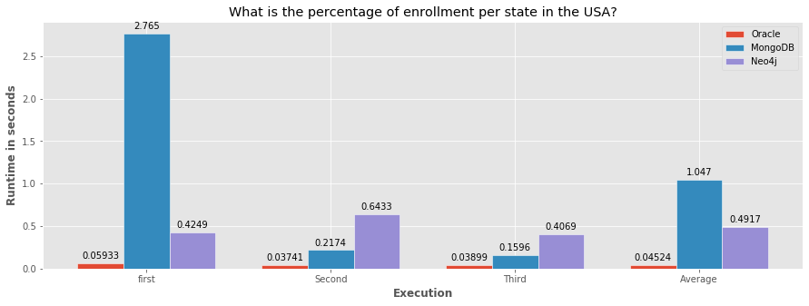

```
{'title': 'What is the percentage of enrollment per state in the USA?'}
         0
0  Oracle
1  MongoDB
2  Neo4j
          0         1         2         3
0  0.059329  0.037415  0.038989  0.045244
1  2.764507  0.217422  0.159571  1.047167
2  0.424864  0.643278  0.406911  0.491684
```

|  | 0 | 1 | 2 | 3 | 4 | 5 | 6 | 7 | 8 | 9 | ... | 38 | 39 | 40 | 41 | 42 | 43 | 44 | 45 | 46 | 47 |
| --- | --- | --- | --- | --- | --- | --- | --- | --- | --- | --- | --- | --- | --- | --- | --- | --- | --- | --- | --- | --- | --- |
| 0 | (California, 10.939627780299592) | (Texas, 10.894235133908307) | (Florida, 7.671357240127099) | (New York, 5.038583749432592) | (Ohio, 4.1307308216069) | (Virginia, 4.0853381752156155) | (Pennsylvania, 3.4498411257376307) | (District of Columbia, 3.3136631865637765) | (Georgia, 2.678166137085792) | (Missouri, 2.451202905129369) | ... | (Hawaii, 0.5901044030867) | (Utah, 0.5447117566954154) | (Alaska, 0.5447117566954154) | (Delaware, 0.45392646391284613) | (Wyoming, 0.22696323195642307) | (South Dakota, 0.18157058556513844) | (Idaho, 0.13617793917385385) | (Rhode Island, 0.13617793917385385) | (North Dakota, 0.13617793917385385) | (Montana, 0.13617793917385385) |
| 1 | {'states': [[{'state': 'Nebraska'}, {'percentage': 0.9532455742169769}], [{'state': 'Arizona'}, {'percentage': 2.0880617339990923}], [{'state': 'Iowa'}, {'percentage': 1.0894235133908308}], [{'state':… | None | None | None | None | None | None | None | None | None | ... | None | None | None | None | None | None | None | None | None | None |
| 2 | (New York, 5.038583749432592) | (Utah, 0.5447117566954154) | (Missouri, 2.451202905129369) | (Kansas, 1.4979573309123921) | (Florida, 7.6713572401271) | (Connecticut, 1.1802088061734) | (Arizona, 2.0880617339990923) | (Virginia, 4.0853381752156155) | (Pennsylvania, 3.4498411257376307) | (Massachusetts, 1.4525646845211075) | ... | (Delaware, 0.45392646391284613) | (Ohio, 4.1307308216069) | (New Jersey, 1.0894235133908308) | (Oklahoma, 1.9518837948252383) | (Idaho, 0.13617793917385385) | (Alaska, 0.5447117566954154) | (Montana, 0.13617793917385385) | (South Dakota, 0.18157058556513844) | (Wyoming, 0.22696323195642307) | (North Dakota, 0.13617793917385385) |

3 rows × 48 columns

```python
####################################################################################################
benchmark_data = init_benchmark_data("What is the percentage of enrollment per state in the USA?")

benchmark_run(query_oracle)
benchmark_run(query_mongodb)
benchmark_run(query_neo4j)

plot_benchmark_data(benchmark_data)
print_benchmark_data(benchmark_data)
####################################################################################################
```